# multilink tutorial

Serge Aleshin-Guendel and Tigran Avoundjian  
June 16, 2023

### Who am I?

- Currently a statistics post-doc at Duke
- Was a Ph.D. student in biostatistics at UW until last fall
- Part of dissertation: developing new probabilistic record linkage methods
- Mauricio Sadinle (advisor) and Julia Hood (PHSKC) wrote a grant to apply these new record linkage methods to data at PHSKC

### Links

- https://github.com/aleshing/multilink_tutorial
- Download the script `multilink_tutorial_code.R`:
  - Click on the script
  - Click on “Raw”
  - Right click “Save as…” `multilink_tutorial_code.R`

[figure not shown]

### Introduction

- `multilink` is an `R` package that performs *probabilistic record linkage*
- *Probabilistic record linkage*: record linkage based on a statistical model
- Developed to handle general problem of multifile record linkage and duplicate detection
- Any number of files to be linked, any of the files may have duplicates

### Introduction

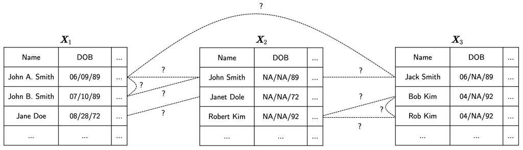

### Introduction

- *Record*: a row of a data set (what we're linking)
- *Field*: a column of a data set (what we're using to link records)

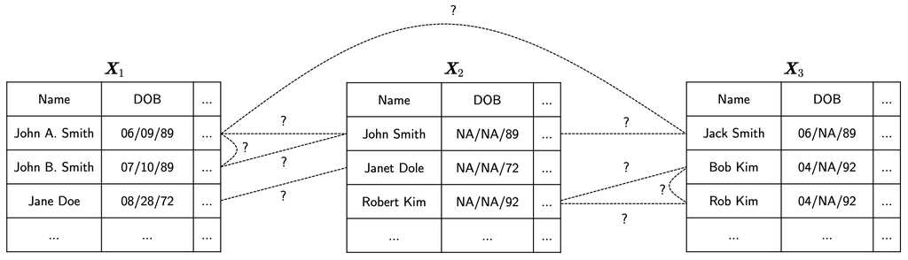

### Introduction

- `multilink` is a *comparison-based* method
- We form a comparison for each field of each record pair
- These comparisons are used to determine which records should be linked
- E.g. suppose your records have first name and age
  - Would form a comparison for first name and a comparison for age for each record pair

### Introduction

- Idea is that similar records are probably matches

| Record | First Name | Last Name | Age |
| --- | --- | --- | --- |
| i | Benedict | Cumberbatch | 40 |
| j | Benedict | Cucumberbatch | 39 |

- And dissimilar records are probably not matches

| Record | First Name | Last Name | Age |
| --- | --- | --- | --- |
| i | Benedict | Cumberbatch | 40 |
| k | Martic | Freeman | 45 |

### Introduction

- `multilink` is a *Bayesian* method
- Possible to quantify uncertainty of the linkage
- Possible to incorporate prior information we may have about the linkage
  - Number of unique individuals we expect to find in the data?
  - Amount of duplication in each file?
  - Amount of overlap between files?
- Tutorial will focus on default settings, in the absence of prior information

### multilink at Public Health — Seattle & King County

- `multilink` has already been used at PHSKC
- Has been used as part of a pipeline to detect “duplicates” in EMS data
- Has been used to link EMS data to vital registration data

### EMS duplicate detection

- Multiple EMS agencies may respond to the same incident
- Each agency generates a record for each person at the incident
- Need to find which records refer to the same person-incident

### EMS and vital stats linkage

- Have person-incident level data of EMS encounters that involved an overdose
- Have person level vital registration data
- Need to find which records refer to the same person
  - Simultaneously merge person-incident level EMS data to become person level EMS data
  - *and* link EMS data to vital registration data

### Links

- Tutorial github: https://github.com/aleshing/multilink_tutorial
- Package github: https://github.com/aleshing/multilink
- CRAN: https://cran.r-project.org/web/packages/multilink/index.html
- Methods paper: https://arxiv.org/abs/2110.03839

### This tutorial

Tutorial using simulated data, composed of two parts:

- Data processing (data cleaning, data formatting, etc.)
- Running `multilink`

### How to follow along

- `R` script `multilink_tutorial_code.R`
- Slides with code will have corresponding code in script
- Run code snippets in the script as we move along

### Package installation

If you haven't already, install the multilink and tidyverse packages

```r
install.packages(c("multilink", "tidyverse"))
```

### Load packages

```r
library(multilink)
library(tidyverse)
```

### Load example data set

Make sure your directory is either set to where this data set lives, or edit the path so that it points to the data set

```r
load("mixed_data_messy.RData")
```

### Explore example data set

`mixed_data_messy` is a list with 6 elements

- `mixed_data_messy_fileX` are data files which we'll link using `multilink`
- `IDs_fileX` are IDs which represent which records are true matches (for evaluation)

```r
names(mixed_data_messy)
```

```
[1] "mixed_data_file1" "mixed_data_file2" "mixed_data_file3" "IDs_file1"
[5] "IDs_file2"        "IDs_file3"
```

### Explore example data set

First file, known a priori to have no duplicate records

```r
head(mixed_data_messy$mixed_data_file1)
```

```
   sex    gname   fname     phone postcode occup
1    m    jarod hugg8ns 726264816      61q  <NA>
2    m    blak3  waller 864645259     6104  <NA>
3 <NA> harrison  varcoe 393726227      606     G
4    f     ruby   boyie 250951820      905  <NA>
5    f   ya5min haskett      <NA>      914  <NA>
6    f   lauren millary 84921z777      6o4     E
```

### Explore example data set

Second file, known a priori to have duplicate records

```r
head(mixed_data_messy$mixed_data_file2)
```

```
   sex     fname     phone postcode   age occup given_name
1    f  halligan      <NA>      715 35-44  <NA>       ella
2    f    oboyle 250951820      904  <NA>     F       ruby
3    m  fearnalx 264057941      607  <NA>     B   dimdothy
4 <NA> fearriall 264057941      617 25-34     B    timothy
5 <NA>      lock 467695008      615  <NA>     C      chl0e
6    m      hnna 781649813      9l3 55-59  <NA>       hugh
```

### Explore example data set

Third file, known a priori to have duplicate records

```r
head(mixed_data_messy$mixed_data_file3)
```

```
      sex    gname    fname     phone postcode   age occup
1       f stephani  everett 4813y2469      602  <NA>     G
2 unknown    jarod  huggins 7w6264816      614  <NA>     F
3       m    tyler  liersch      <NA>      61s  <NA>     A
4 unknown     ruby    boyoe 250951820      905  <NA>     F
5       m   tlmthy vearnall 264057941      607 25-34  <NA>
6       m   robbie    dakid 362144933      607 45-54  <NA>
```

### Data processing

- All of the stuff you have to do before running a linkage
  - Data cleaning
  - Data formatting
- Arguably the most important part of using any software for record linkage
- We'll cover how data needs to be formatted for `multilink`
- However, the data cleaning we do is broadly applicable

### multilink data format

Data will enter `multilink` through the following inputs:

- `file_sizes`: a `numeric` vector the indicates the size of each file
  - I.e. the number of records (rows) in each file
- `duplicates`: a `numeric` vector that indicates which files are assumed to have “duplicates” a priori

### multilink data format

Data will enter `multilink` through the following inputs:

- `records`: a `data.frame` containing all records to be linked, where each column is a field that will be compared.
  - Any columns not meant for linkage (e.g. row IDs) should be removed.
  - Missing values need to be explicitly coded as `NA`.
  - If there are multiple files, `records` should be obtained by stacking each file on top of each other after fields are aligned.

### Aside: Which fields should you use?

- Choosing which fields enter the linkage is important!
- Need fields which are *identifying*
  - Name, DOB, age, race, sex, etc.
- Need fields from different files to be *comparable* and *recording the same information*
  - Need to be careful with times, dates, locations, etc.
- Would like to have fields that are recorded with minimal error
  - Not always possible

### multilink data format

Data will enter `multilink` through the following inputs:

- `type`: a `character` vector, indicating the comparison type to be used for each field (i.e. each column of `records`).
  - “`bi`”: binary comparison
  - “`nu`”: numeric comparison (using absolute difference)
  - “`lv`”: string comparison (using normalized Levenshtein distance)
  - “`lv_sep`”: string comparison (using normalized Levenshtein distance) when each string may contain multiple spellings, separated by the “|” character

### Aside: String Comparison Details

- *Levenshtein distance*: Minimum number of single-character edits (insertions, deletions, substitutions) needs to change one word into another
- *normalized Levenshtein distance*: Levenshtein distance normalized by the longer of the two strings
- Suppose you have strings `s_1` and `s_2`
- Assume `s_1` is length `L`, and is longer than `s_2`
- A normalized Levenshtein distance of 0.5 means that the minimum number of single-character edits to change `s_1` to `s_2` is `L/2`

### multilink data format

Data will enter `multilink` through the following inputs:

- `type`: a `character` vector, indicating the comparison type to be used for each field (i.e. each column of `records`).
  - Fields using “`bi`”, “`lv`”, or “`lv_sep`” must be of class `character`
  - Fields using “`nu`” must be of class `numeric`
  - Fields using “`bi`”, “`lv`”, or “`lv_sep`” are case-sensitive

### multilink data format

We'll now demonstrate how to form each of these inputs

### Make file_sizes and duplicates

First, we'll form file_sizes

```r
file_sizes <-
  c(nrow(mixed_data_messy$mixed_data_file1),
    nrow(mixed_data_messy$mixed_data_file2),
    nrow(mixed_data_messy$mixed_data_file3))

file_sizes
```

```
[1] 181 288 292
```

### Make file_sizes and duplicates

Next, we'll form duplicates. `0` corresponds to no duplicates in a file, `1` corresponds to duplicates in a file.

```r
duplicates <- c(0, 1, 1)
```

### Make records

To form `records`, we need to clean up to data appropriately:

- Recode missing fields to `NA`.
- Align fields.
- Stack files.

### Recode missing values

The fields in each file already have missing values coded as NA, except for the field `sex` in `mixed_data_file3`. In this file, missing values of `sex` are coded as `unknown`. Let’s recode these missing values to `NA`.

```r
mixed_data_messy$mixed_data_file3 <-
  mixed_data_messy$mixed_data_file3 %>%
  mutate(sex = ifelse(sex == "unknown",
                      NA, sex))
```

### Recode missing values

- When a record contains missing fields, `multilink` uses only the non-missing fields of the record to determine if it matches to other records.
- Need to make sure you capture *all* missing values
  - E.g. if “John Doe” is used for a person that is missing first and last name, need to recode to be missing

### Align fields

- The fields in each file need to be “aligned” so that they can eventually be stacked together.
- What we mean by “aligned”: the columns of each file need to all have the same names when referring to the same fields and need to be all be in the same order.
- We need to do a few tasks to align the three files.

### Align fields

First, `mixed_data_file1` is missing the `age` field. Thus we need to create a column `age` in `mixed_data_file1` that has `age` as missing for each record.

```r
mixed_data_messy$mixed_data_file1 <-
  mixed_data_messy$mixed_data_file1 %>%
  mutate(age = NA)
```

### Align fields

Next, in `mixed_data_file2` the column recording given name is called `given_name`, rather than `gname` as in the two other files. Thus we need to rename the `given_name` column in `mixed_data_file2` to `gname`.

```r
mixed_data_messy$mixed_data_file2 <-
  mixed_data_messy$mixed_data_file2 %>%
  rename(gname = given_name)
```

### Align fields

Finally, the order of the columns are different in each file. Let’s reorder the first two files so that they’re in the same order as the third file.

```r
colnames(mixed_data_messy$mixed_data_file3)
```

```
[1] "sex"      "gname"    "fname"    "phone"    "postcode" "age"      "occup"
```

### Align fields

Finally, the order of the columns are different in each file. Let’s reorder the first two files so that they’re in the same order as the third file.

```r
mixed_data_messy$mixed_data_file1 <-
  mixed_data_messy$mixed_data_file1 %>%
  select(sex, gname, fname, phone, postcode, age, occup)

mixed_data_messy$mixed_data_file2 <-
  mixed_data_messy$mixed_data_file2 %>%
  select(sex, gname, fname, phone, postcode, age, occup)
```

### Stack files

After cleaning the data files, we're ready to stack them and form `records`:

```r
records <-
  rbind(mixed_data_messy$mixed_data_file1,
        mixed_data_messy$mixed_data_file2,
        mixed_data_messy$mixed_data_file3)
```

### Make types

We will be using string comparisons for `gname`, `fname`, `phone`, and `postcode`, and binary comparisons for the rest of the fields.

```r
types <- c("bi", "lv", "lv", "lv", "lv", "bi", "bi")
```

### Make types

- As we're using binary or string comparisons for all fields, we need the fields to be of class `character`.
- This is already done in our example data set, however it’s important to check this before running `multilink`.

```r
class(records$gname)
```

```
[1] "character"
```

### Make types

- Converting fields to class character can be accomplished as follows using the mutate and as.character functions:

```r
records <- records %>%
  mutate(gname = as.character(gname))
```

### Running multilink

- We've successfully processed our data, so we can now run `multilink` to link the records.
- Running `multilink` can be broken down into a pipeline of 6 steps

### Running multilink

1. Perform blocking
2. Creating comparison data: `create_comparison_data`
3. Reducing comparison data: `reduce_comparison_data`
4. Specifying prior information: `specify_prior`
5. Explore the space of linkages: `gibbs_sampler`
6. Find the best linkage: `find_bayes_estimate` and `relabel_bayes_estimate`

### Step 1: Perform blocking

- As we'll see, creating comparison data can be very computationally costly
- If there are `r` records, in the worst case, there are `r`x`r` comparisons
- Want to avoid if possible forming comparisons for record pairs that are unlikely to be matches
- One way to do this is through *blocking*
- Can also help improve quality of linkage

### Step 1: Perform blocking

Main idea for blocking:

- Suppose we have some fields that are not missing and known to be recorded with minimal error.
- Break the data up into *blocks* of records that agree on these fields.
- Perform record linkage separately on each block.

### Step 1: Perform blocking

Some suggestions for performing blocking:

- If you have fields that are reliable, block!
- Field reliability depends on application, some possibilities:
  - First letter of a first or last name
  - Birth Year
  - Zip code
- If you have more than ~5,000 total records, try to find a field or transformation of a field that is reliable enough to block.

### Step 1: Perform blocking

Our example data set is small enough to not need blocking, and messy enough that finding a reliable field is not feasible

### Step 2: Create comparison data

- We're almost ready to create the comparison data, one argument left to specify
- For non-binary comparisons, we need to specify breakpoints to discretize the comparisons
  - String comparisons fall in the range [0,1]
  - We recommend as a default breaking this range into the following intervals:
  - {0}, (0, 0.25], (0.25, 0.5], (0.5, 1]
  - These intervals then correspond to exact agreement, high agreement, medium agreement, and low agreement

### Step 2: Create comparison data

`breaks` is a `list` that records breakpoints for each field being compared. For fields that use binary comparisons, can set the corresponding element to `NA`.

```r
breaks = list(sex = NA,
              gname = c(0, 0.25, 0.5),
              fname = c(0, 0.25, 0.5),
              phone = c(0, 0.25, 0.5),
              postcode = c(0, 0.25, 0.5),
              age = NA,
              occup = NA)
```

### Step 2: Create comparison data

We can now create the comparison data!

```r
comparison_list <- create_comparison_data(records = records,
                                          types = types,
                                          breaks = breaks,
                                          file_sizes = file_sizes,
                                          duplicates = duplicates)
```

```
[1] "Creating comparison data for field sex"
[1] "Creating comparison data for field gname"
[1] "Creating comparison data for field fname"
[1] "Creating comparison data for field phone"
[1] "Creating comparison data for field postcode"
[1] "Creating comparison data for field age"
[1] "Creating comparison data for field occup"
```

### Step 2: Create comparison data

`comparison_list$comparisons` contains the discretized comparisons for each record pair. columns labelled with “… `_DL_0`” represent the highest level of agreement.

```r
head(comparison_list$comparisons[, 1:6])
```

```
     sex_DL_0 sex_DL_1 gname_DL_0 gname_DL_1 gname_DL_2 gname_DL_3
[1,]    FALSE     TRUE      FALSE      FALSE      FALSE       TRUE
[2,]    FALSE     TRUE      FALSE      FALSE      FALSE       TRUE
[3,]     TRUE    FALSE      FALSE      FALSE      FALSE       TRUE
[4,]    FALSE    FALSE      FALSE      FALSE      FALSE       TRUE
[5,]    FALSE    FALSE      FALSE      FALSE      FALSE       TRUE
[6,]     TRUE    FALSE      FALSE      FALSE      FALSE       TRUE
```

### Step 2: Create comparison data

`comparison_list$record_pairs` contains the record pairs being compared in the corresponding rows of `comparison_list$comparisons`

```r
head(comparison_list$record_pairs)
```

```
  i   j
1 1 182
2 1 183
3 1 184
4 1 185
5 1 186
6 1 187
```

### Step 3: Reduce comparison data

- We have already discussed how blocking can be used to reduce the computational cost of record linkage
- Another related method is *indexing*
- Indexing is another method for reducing the number of record pairs that are potential matches
- Performed *after* comparison data has already been created (blocking is done before)

### Step 3: Reduce comparison data

Main idea for indexing:

- Specify a rule using non-missing fields, and potentially other data not being used in the linkage
- Apply the rule to each record pair to determine if the record pair is kept as a potential match
- Perform the record linkage on the record pairs kept as potential matches

### Step 3: Reduce comparison data

Recall that we broke string comparisons up into:

- exact agreement, high agreement, medium agreement, and low agreement

We will use the following rule:

- Keep record pairs as potential matches if both `gname` and `fname` are *not* low agreement

We specify this rule in `R` as a `logical` vector `pairs_to_keep`, the same length as the number of record pairs. `pairs_to_keep` being true for a record pair indicates that the pair is a potential match.

### Step 3: Reduce comparison data

Record pairs for which both `gname` and `fname` are *not* low agreement are potential matches.

```r
pairs_to_keep <-
  (comparison_list$comparisons[, "gname_DL_3"] == FALSE) &
  (comparison_list$comparisons[, "fname_DL_3"] == FALSE)
```

### Step 3: Reduce comparison data

We can now reduce the comparison data!

```r
reduced_comparison_list <-
  reduce_comparison_data(comparison_list = comparison_list,
                         pairs_to_keep = pairs_to_keep,
                         cc = 1)
```

### Step 4: Specify prior information

- The next step is to specify prior information for our model.
- We will rely on default values for most prior information.
- One part of the prior information that should not use a default is `dup_upper_bound`.
- This is a `numeric` vector, indicating the maximum number of duplicates that could appear in a given file

### Step 4: Specify prior information

- For example, if `dup_upper_bound` is 10 for a file, we're indicating that it's not possible for an individual to have more than 10 duplicate records associated with them
- For files known to have no duplciates, `dup_upper_bound` should be 1
- In most applications, it is reasonable to set the upper bound for a file to be 10-20.

```r
dup_upper_bound <- c(1, 10, 10)
```

### Step 4: Specify prior information

We can now specify the prior information!

```r
prior_list <- specify_prior(comparison_list = reduced_comparison_list,
                            mus = NA,
                            nus = NA,
                            flat = 0,
                            alphas = NA,
                            dup_upper_bound = dup_upper_bound,
                            dup_count_prior_family = NA,
                            dup_count_prior_pars = NA,
                            n_prior_family = NA,
                            n_prior_pars = NA)
```

### Step 5: Explore the space of linkages

- The next step is to explore the space of linkages using `gibbs_sampler`.
- `multilink` uses a Gibbs sampler, an iterative computational method, which produces a sequence of linkage samples
- `n_iter` is the number of iterations to run the Gibbs sampler.
- We recommend setting `n_iter` to at least 2,000.

```r
n_iter <- 2000
```

### Step 5: Explore the space of linkages

- `seed` is specified for reproducibility. If all inputs to `gibbs_sampler` are the same including `seed`, rerunning the function will produce the same output.

```r
seed <- 44
```

### Step 5: Explore the space of linkages

We can now explore the space of linkages!

```r
results <- gibbs_sampler(comparison_list = reduced_comparison_list,
                         prior_list = prior_list,
                         n_iter = n_iter,
                         seed = seed)
```

```
[1] "Running Gibbs sampler with Gibbs updates to partition."
[1] "Processing inputs"
[1] "Beginning sampling"
Beginning iteration 1/2000
Beginning iteration 100/2000
Beginning iteration 200/2000
Beginning iteration 300/2000
Beginning iteration 400/2000
Beginning iteration 500/2000
Beginning iteration 600/2000
Beginning iteration 700/2000
Beginning iteration 800/2000
Beginning iteration 900/2000
Beginning iteration 1000/2000
Beginning iteration 1100/2000
Beginning iteration 1200/2000
Beginning iteration 1300/2000
Beginning iteration 1400/2000
Beginning iteration 1500/2000
Beginning iteration 1600/2000
Beginning iteration 1700/2000
Beginning iteration 1800/2000
Beginning iteration 1900/2000
Beginning iteration 2000/2000
[1] "Finished sampling in 2.51647901535034 seconds"
```

### Step 6: Find the best linkage

- `gibbs_sampler` outputs a collection of linkages, but we usually want one final linkage to use for downstream tasks
- `find_bayes_estimate` is used to find the best linkage based on the output of `gibbs_sampler`

### Step 6: Find the best linkage

To find the best linkage based on the output of `gibbs_sampler`, we need to specify two arguments `burn_in` and `max_cc_size`.

- `burn_in` is a value between 0 and `n_iter` that indicates how many iterations of the Gibbs sampler to discard for “burn-in”. We recommend setting `burn_in` so that `n_iter` - `burn_in` is at least 1,000.
- Because the Gibbs sampler we used is iterative, it needs some time to converge (informally). Burn-in removes some initial number of samples from when the Gibbs sampler may not have converged yet.

```r
burn_in <- 1000
```

### Step 6: Find the best linkage

To find the best linkage based on the output of `gibbs_sampler`, we need to specify two arguments `burn_in` and `max_cc_size`.

- `max_cc_size` controls the computation cost of finding the best linkage, at the cost of accuracy.
- Higher `max_cc_size` leads to higher cost, but a more accurate linkage
- Lower `max_cc_size` leads to lower cost, but a less accurate linkage
- We recommend setting this to a default of 50.

```r
max_cc_size <- 50
```

### Step 6: Find the best linkage

We can now find the best linkage!

```r
full_estimate <- find_bayes_estimate(partitions = results$partitions,
                                     burn_in = burn_in,
                                     max_cc_size = max_cc_size)
```

```
[1] "Finding Bayes estimate with a threshold of 0 and a maximum connected component of size 6"
```

### Step 6: Find the best linkage

- As we used `reduce_comparison_data`, we now need to use `relabel_bayes_estimate`
- `relabel_bayes_estimate` lines up our estimated linkage with records that were originally input into `create_comparison_data`

```r
full_estimate_relabel <-
  relabel_bayes_estimate(reduced_comparison_list = reduced_comparison_list,
                         bayes_estimate = full_estimate)
```

### Step 6: Find the best linkage

- And finally, we can combine our estimated linkage with the original records to examine which records `multilink` declared as matches
- Two records having the same `full_estimate_id` here indicates that `multilink` declared them as matches

```r
records <- cbind(records,
                 full_estimate_id = full_estimate_relabel$link_id)

head(records)
```

```
   sex    gname   fname     phone postcode  age occup full_estimate_id
1    m    jarod hugg8ns 726264816      61q <NA>  <NA>                1
2    m    blak3  waller 864645259     6104 <NA>  <NA>              200
3 <NA> harrison  varcoe 393726227      606 <NA>     G              201
4    f     ruby   boyie 250951820      905 <NA>  <NA>                2
5    f   ya5min haskett      <NA>      914 <NA>  <NA>              202
6    f   lauren millary 84921z777      6o4 <NA>     E              203
```

### Step 6: Find the best linkage

```r
head(records %>% arrange(full_estimate_id))
```

```
   sex gname    fname     phone postcode  age occup full_estimate_id
1    m jarod  hugg8ns 726264816      61q <NA>  <NA>                1
2 <NA> jarod  huggins 7w6264816      614 <NA>     F                1
3    f  ruby    boyie 250951820      905 <NA>  <NA>                2
4    f  ruby   oboyle 250951820      904 <NA>     F                2
5 <NA>  ruby    boyoe 250951820      905 <NA>     F                2
6 <NA>  liam berryman 719556628      6o7 <NA>     B                3
```

### Conclusion

Any questions?

- Email: saleshinguendel@gmail.com